# Spatial Early Warning Signals Results Summary - SST and Heatwave Analysis

3 December 2020

# SST and Marine heatwaves

### Summary

Question 1: Is there an early warning signal leading up to the 2012 heatwave event? Answer 1: I don’t think so. Based on Figure 2. It looks like the change in variance and skewness occur during/after the events with a smaller reaction to a 2006 event occuring earlier on in the ts. So I don’t think that this is showing up what we are looking for.

Question 2: How can we link the heatwaves EWS to SST SEWS? Answer 2: Both show seasonality in variation - Greater variation in the summer months and lower variation in the winter months. The SD is increasing in heatwaves EWS but relative variation (CV) is not. The Spatial Early Warnings analysis calculates variance using the base `r` function `var`.

Question 3: Is it possible to “predict” a major heatwave event using EWS? Answer 3: I dont think so. There is nothing in the break down of the dataset leading up to the large marine heatwave event in the summer of 2012. The dataset goes up to April 2012 and the heatwave event starts in May 2012 and there does not seem to be anything in that analysis that indicates an obvious shift is about to occur.

## Monthly heatwave early warning signals

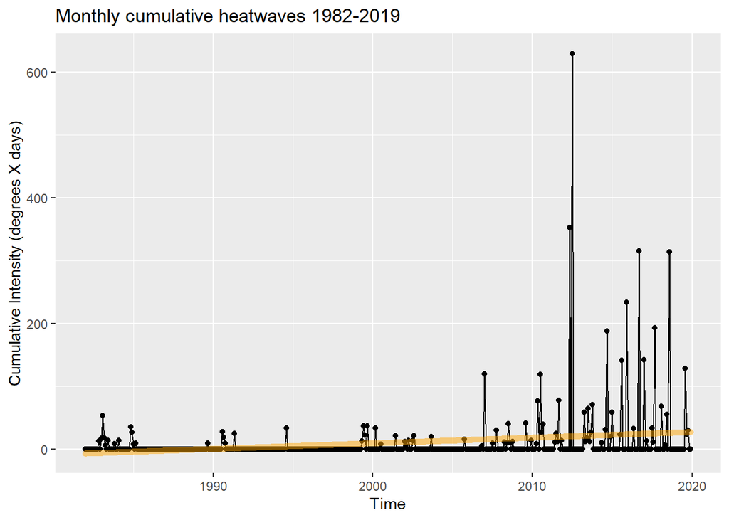

Time-series early warnings - analysis of monthly heatwave timeseries. Window size presented is 50% other window sizes were explored and can be found [here](https://kimberly-bastille.github.io/sp-warnings/summary_sst). This analysis uses the `generic_ews()` function in the `earlywarnings package`.

**RED LINE = 2012 MAJOR HEATWAVE EVENT**

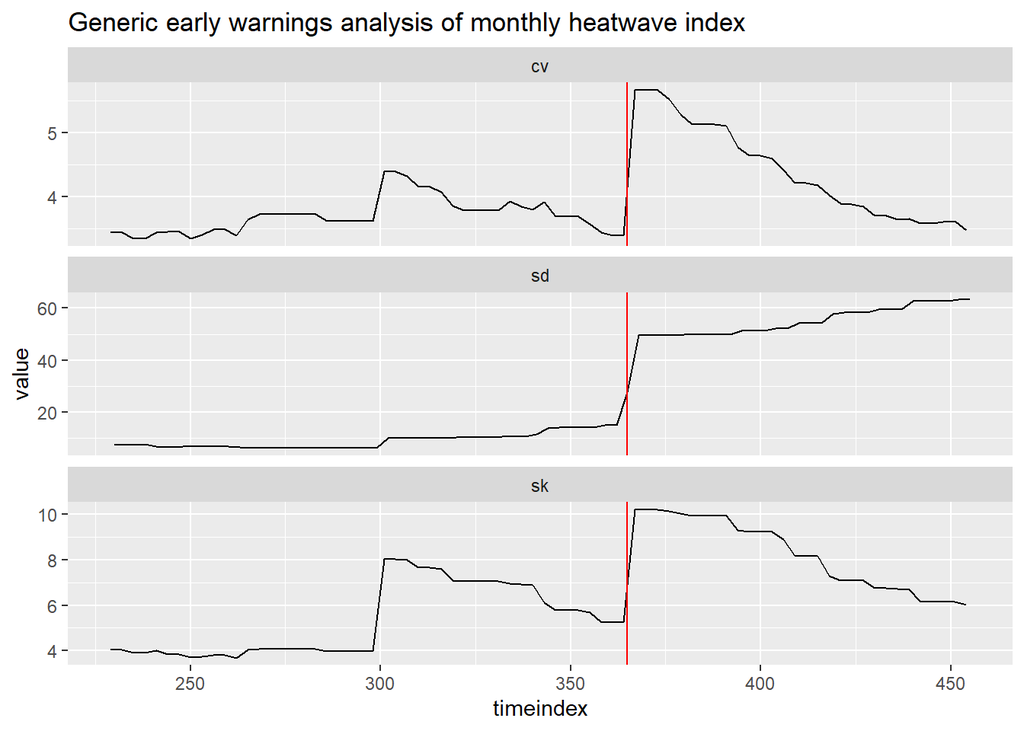

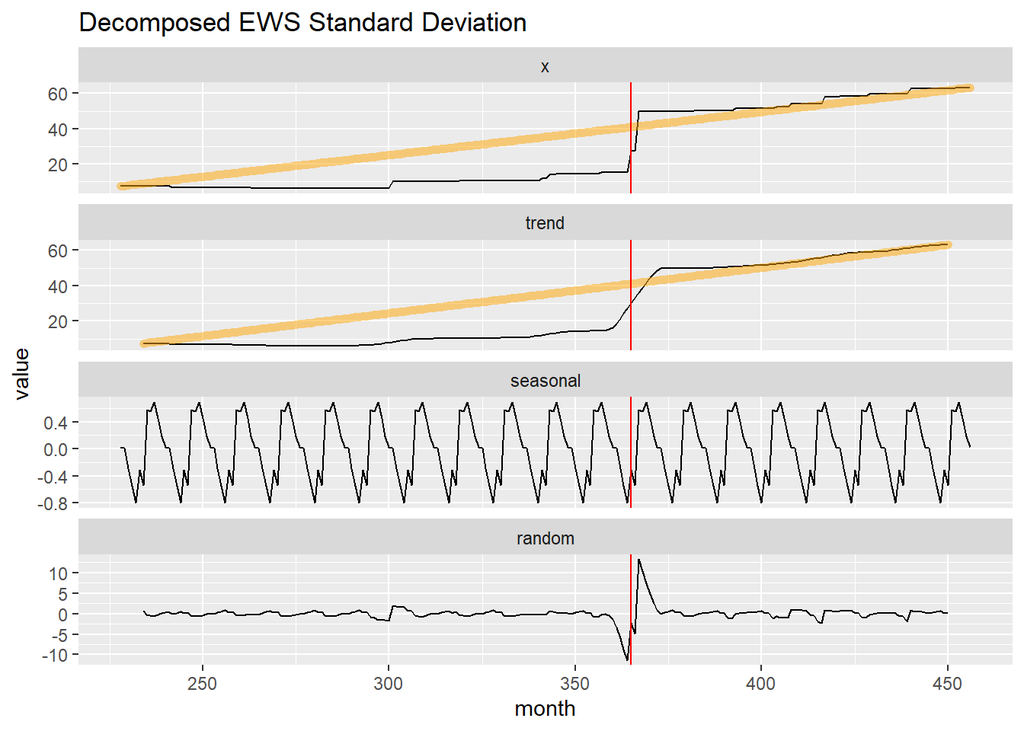

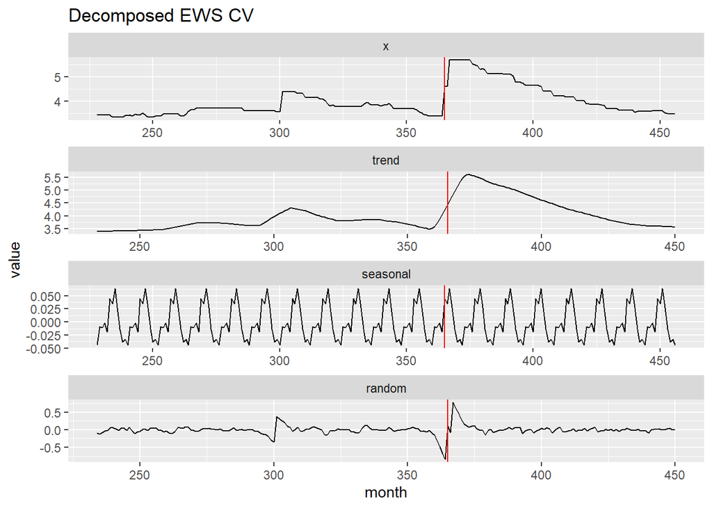

#### Data Background

Heatwaves were calculated using the `heatwaveR` package and the flickering dataset produced shows the cumulative heatwave calculations for each month. If the heatwave occured in more than one month the peak temperature date (output from `heatwaveR`) was used.

Data range = 1982 to 2019 and covers the Gulf of Maine.

## Marine Heatwave Data up to summer 2012

This dataset is filtered to only include data leading up to the large marine heatwave in the summer of 2012. (Data stops in April 2012)

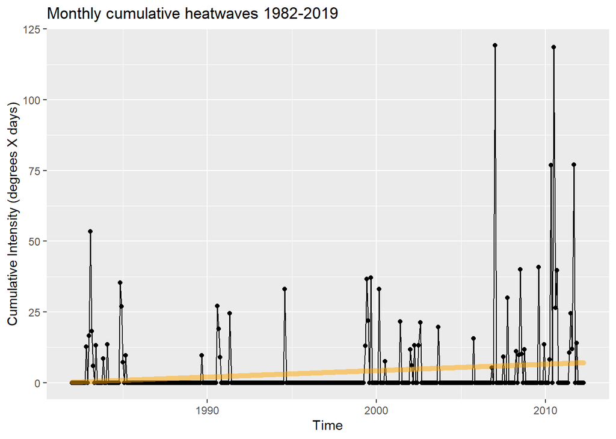

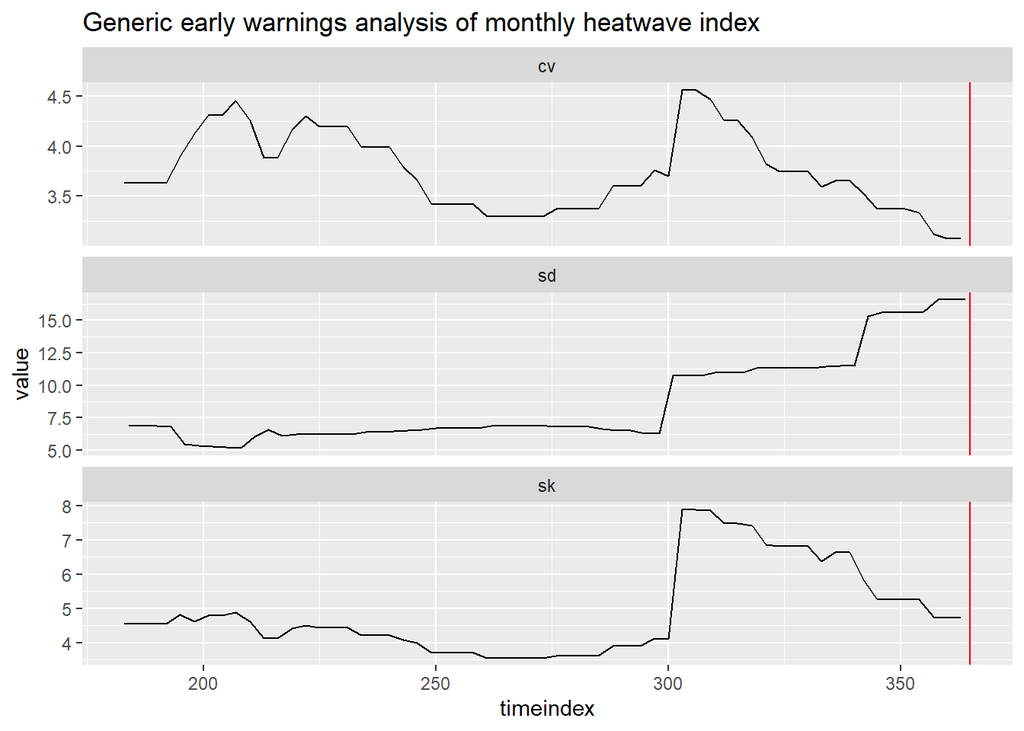

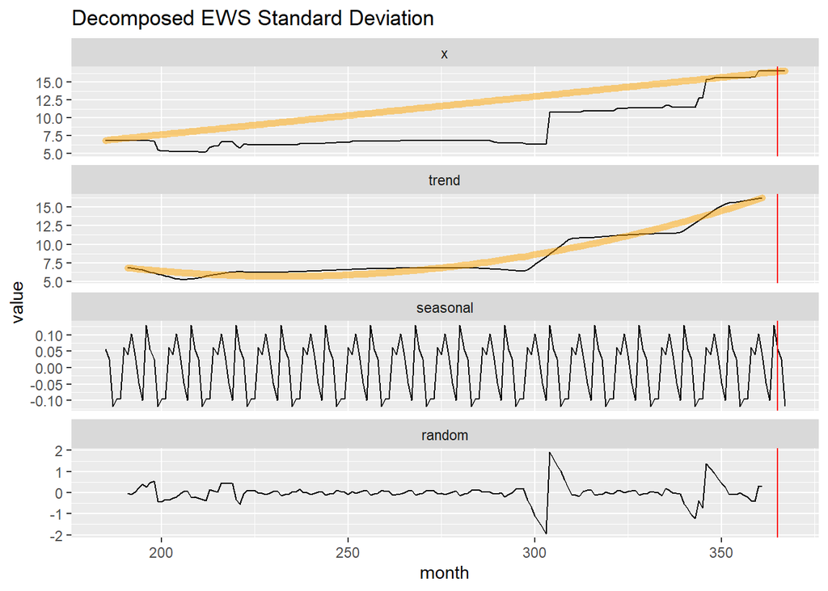

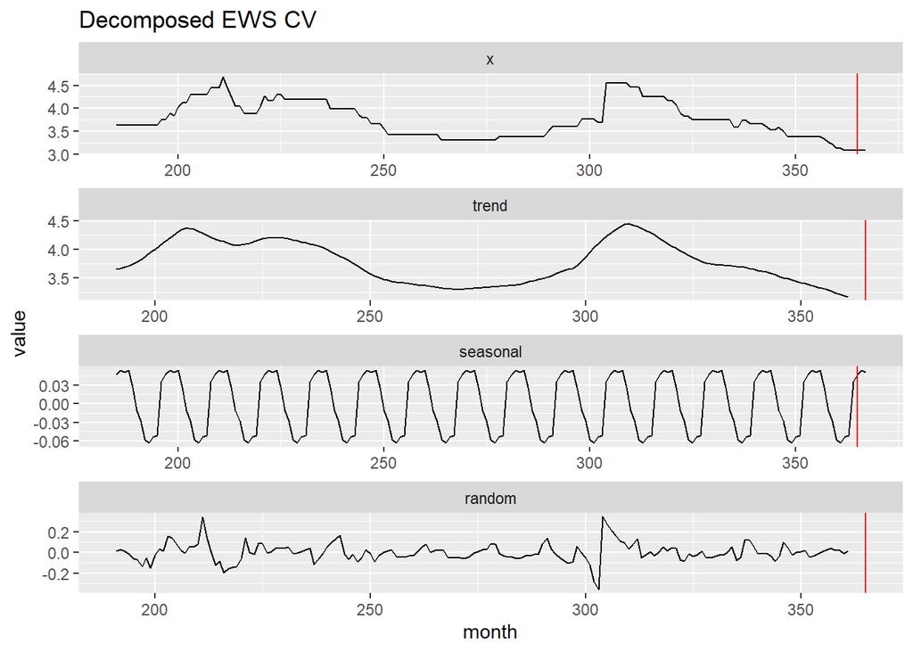

#### Data Background

Heatwaves were calculated using the `heatwaveR` package and the flickering dataset produced shows the cumulative heatwave calculations for each month. If the heatwave occured in more than one month the peak temperature date (output from `heatwaveR`) was used.

Data range = 1982 to 2012 and covers the Gulf of Maine.

## Decomposition of the GOM SST spatial variance.

Spatial early warnings - Analysis or spatial variance for each monthly raster grid.

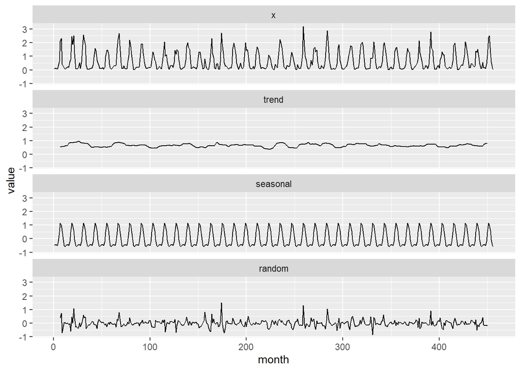

### Data Background

SST data comes from NOAA Physical Science Laboratory [OISST V2 High Resolution Dataset](https://psl.noaa.gov/data/gridded/data.noaa.oisst.v2.highres.html).

Data range = 1982 to 2019, 0.25 degree pixels masked to the EPUs of the NEUS shelf. This analysis only covers the Gulf of Maine EPU.

Data gathered into monthly sst rasters using this [code](https://github.com/kimberly-bastille/sp-warnings/blob/master/R/get_monthly_sst.R)